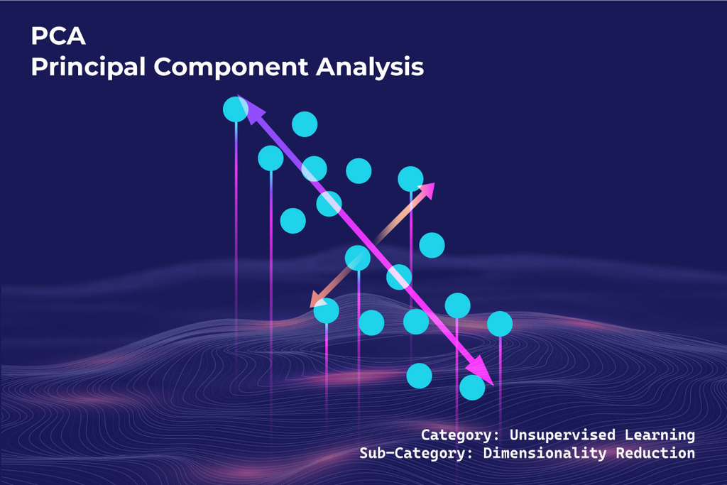

# Authors

| Hector R. Gavilanes | Chief Information Officer |
| --- | --- |
| Gail Han | Chief Operating Officer |
| Michael Mezzano | Chief Technology Officer |

University of West Florida

November 2023

# What is PCA?

- Principal Component Analysis (PCA)
- Dimensionality reduction technique.
- Purpose:
  - Simplification of complex datasets.
  - Preservation of essential information.

# Why Use PCA?

- Reducing Dimensionality: Simplify high-dimensional data.
- Visualizing Data: Help visualize data in lower dimensions.
- Noise Reduction: Eliminate less relevant features.
- Improved Model Performance: Enhance machine learning efficiency.

# Methods

- Data Matrix: Start with a matrix X of size n x m.
- Centering: Subtract the mean of each feature.
- Covariance Matrix: Calculate the covariance matrix of the centered data.
- Select Principal Components: Choose top eigenvectors.

# Singular Value Decomposition (SVD)

- Eigenvectors: Represent directions of maximum variance.
- Eigenvalues: Indicate the variance explained by each eigenvector.
- Sorting: Sort eigenvalues in descending order to select the most significant components.

# Variance Explained

- Explained Variance Ratio: Calculate the ratio of each eigenvalue.
- Cumulative Variance: Plot cumulative explained variance to determine components to retain.

## Objective

- Weighted Combination
- Maximal Variance Components

### High Variance vs

### Low Variance

[figure not shown]

# Dimensionality Reduction

- Unsupervised Learning.
- Reduce Dimensions: Transform data by multiplying with selected eigenvectors.
- New Feature Space: Data exists in a lower-dimensional feature space.

# Visualization

- Data Projection: Visualize data in the reduced feature space.
- Scatterplots: Use scatterplots to visualize data distribution.

# Assumptions and Limitations

- Interpretability: Loss of interpretability in transformed features.
- Loss of Information: Reducing dimensionality may result in some information loss.
- Scaling: Data scaling is important to avoid feature dominance.

# Applications of PCA

- Image Compression: Reduce image size while preserving details.
- Face Recognition: Reduce facial feature dimensions for classification.
- Anomaly Detection: Identify anomalies in large datasets.
- Bioinformatics: Analyze gene expression data.

# Dataset

- Overview
- Description
- Source
- 39 variables, or features.
- 56 Observations.
- “State” represents 50 states & 6 U.S. territories.
- Administered to In-Center Hemodialysis Survey.
- State-level averages.
- Dialysis Quality measures.
- Released on July 19, 2023.
- [data.cms.gov.](https://data.cms.gov/provider-data/dataset/2fpu-cgbb)

Data Obtained from “Consumer Assessment of

Healthcare Providers and Systems (CAHPS).”

# Variables / Features

- Index
- Response
- Dialysis
- 39 variables, or features.
- 56 observations.
- “State” represents 50 states & 6 U.S. territories.
- Categorical index feature removed from model.
- 24 features: patient care quality ratings,
- Transfusions, fistula usage, infections,
- Hospitalizations, incident waitlisting & readmissions.
- 14 features: dialysis adequacy (Kt/V), type of dialysis,
- Serum phosphorus level, & average hemoglobin level,
- Normalized protein catabolic rate (nPCR), hypercalcemia level.

# Dataset

- Overview
- Description
- Patient Care
- Dialysis
- Source
- 39 variables, or features.
- 56 observations.
- State-level averages.
- “State” represents 50 states & 6 U.S. territories.
- Administered to In-Center Hemodialysis Survey.
- Dialysis Quality measures.
- 24 features: patient care quality ratings,
- Transfusions, fistula usage, infections,
- Hospitalizations, incident waitlisting & readmissions.
- 14 features: dialysis adequacy (Kt/V), type of dialysis,
- Serum phosphorus level, & average hemoglobin level,
- Normalized protein catabolic rate (nPCR), hypercalcemia level.
- Released on July 19, 2023.
- [data.cms.gov.](https://data.cms.gov/provider-data/dataset/2fpu-cgbb)

# Dataset Summary

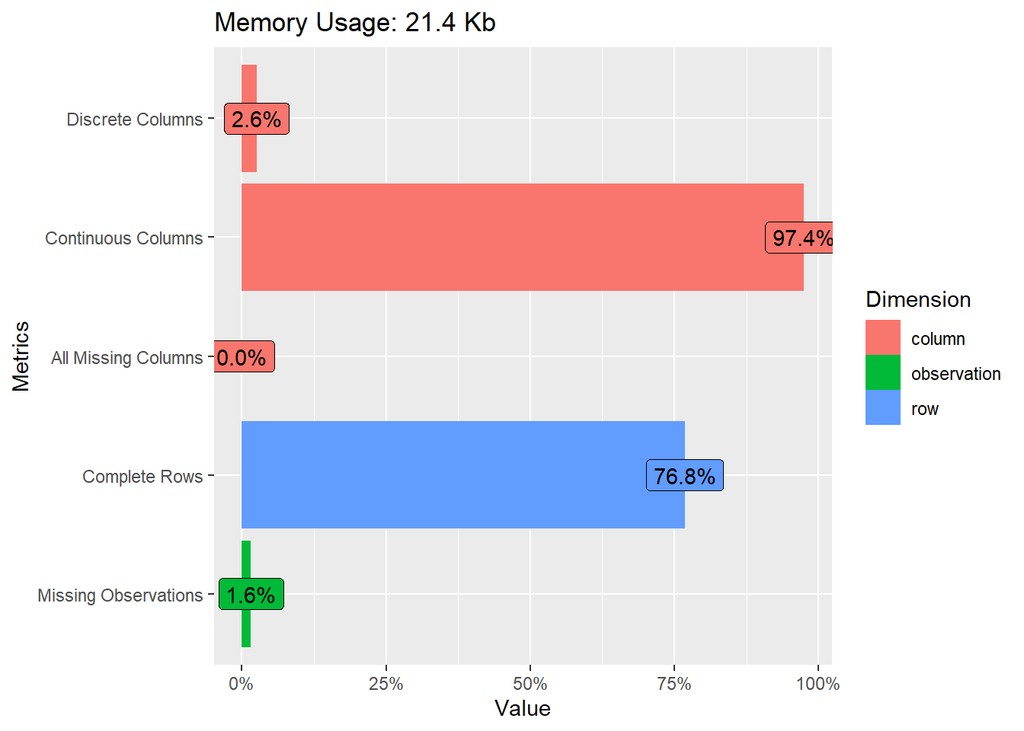

- PCA is designed for continuous numerical data.
- Categorical index feature removed from model.

# Dataset Selection Rationale

# Data Preparation

- Editing
- Example
- Efficient removal of white spaces in the dataset.
- Editing variable names to enhance readability and meaningful.

`Original:` “Percentage.Of.Adult..Patients.With.Hypercalcemia..Serum.Calcium.Greater.Than.10.2.Mg.dL.”

`Edited:` “hypercalcemia_calcium > 10.2Mg.”

# Missing Values

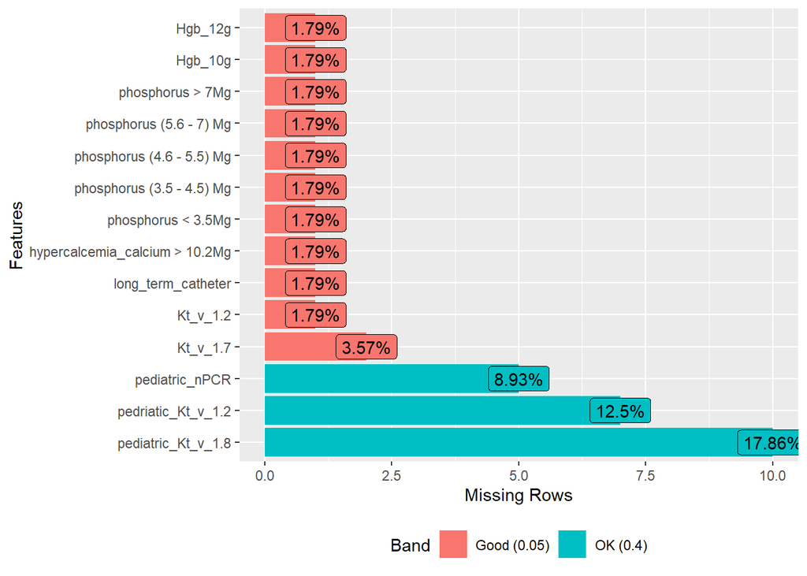

- 34 missing values.
- Imputation of missing values using the $Mean$ ($\mu$)

# Distribution

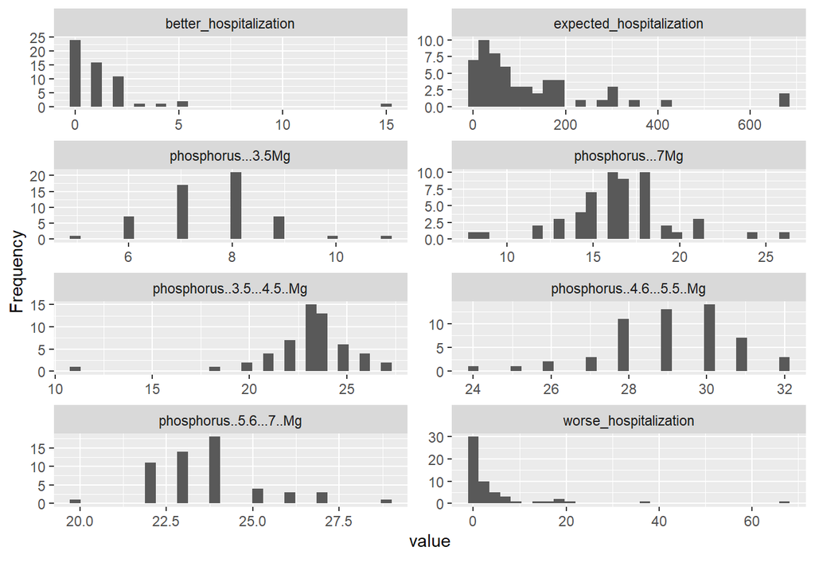

- Normality is not assumed.

# QQ-Plot of Residuals

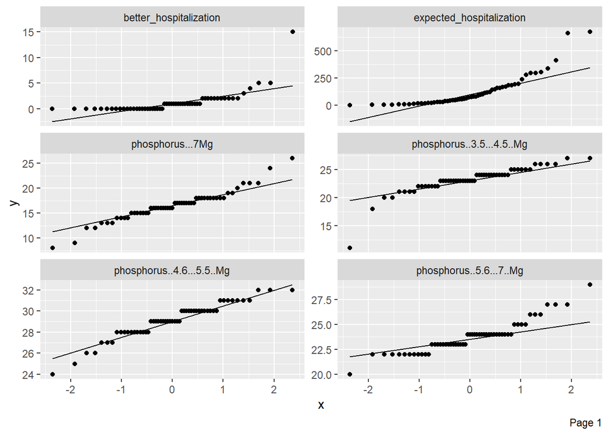

- Outliers are present through the entire dataset

# Standardization

- Mean ($\mu$=0); Standard Deviation ($\sigma$= 1)

  $$Z = \frac{{ x - \mu }}{{ \sigma }}$$

  $$Z \sim N(0,1)$$

# Outliers & Leverage

- 3 Outliers
- No leverage

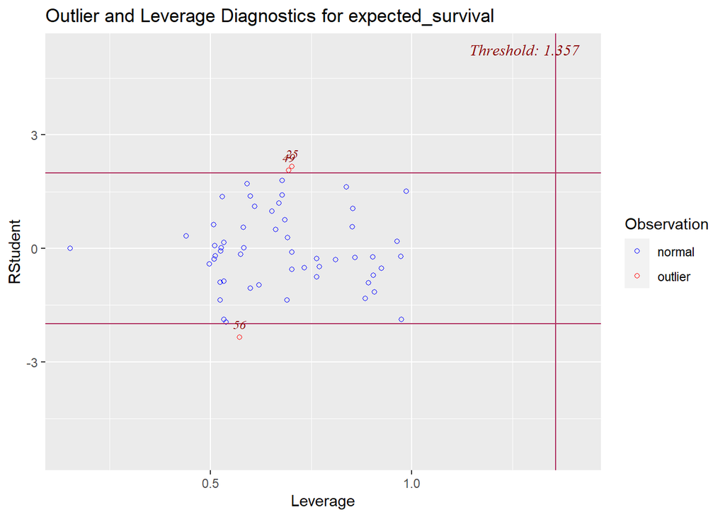

- Minimal difference.
- No observations removed.

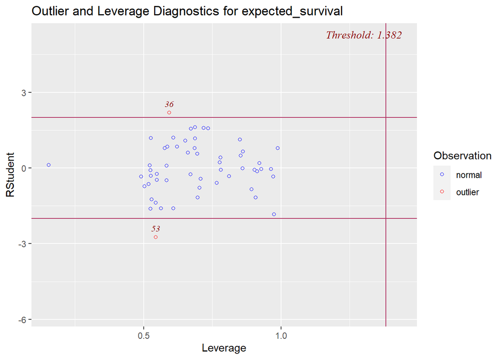

# PCA in Machine Learning

- Feature Selection: Use PCA to select relevant features.
- Model Training: Enhance model performance by reducing dimensionality.
- Preprocessing: Standardize and normalize data before applying PCA.

# Conclusion

- Summary: PCA is an unsupervised learning technique for dimensionality reduction and data visualization.
- Key Takeaways: Understand eigenvectors, eigenvalues, and explained variance.

# Questions

- Open the floor for questions from the audience.

# Thank You

# References